# Analyse de la consommation de Gaz en Résidence

Christian YOBA

2026-03-18

## Useful R packages

```r
library(RMariaDB)
library(getPass)
library(FactoMineR)
library(factoextra)
library(rlang)
library(bookdown)
library(dplyr)
library(knitr)
library(kableExtra)
```

# 1 Contexte et Objectifs de l’étude

**Contexte**

Dans le cadre de la gestion énergétique d’une maison de repos, ce projet porte sur l’analyse de la consommation de gaz naturel relevée sur 17 sites résidentiels. Face à la hausse des coûts énergétiques et aux exigences croissantes en matière de durabilité, il devient essentiel de comprendre et anticiper les comportements de consommation pour mieux cibler les actions d’optimisation. Les données, stockées dans une base relationnelle, sont extraites et analysées entièrement sous R, depuis la connexion SQL jusqu’à la modélisation statistique et la classification des sites.

**Objectifs**

- Modéliser la relation entre consommation et conditions climatiques Quantifier l’impact des températures extérieures sur la consommation de gaz via une régression linéaire basée sur la variable Degré Jour, et évaluer l’influence des effets saisonniers mensuels.
- Identifier les profils de consommation des sites À partir des consommations moyennes mensuelles, appliquer une Analyse en Composantes Principales (ACP) et une analyse en clusters pour regrouper les sites selon leurs comportements similaires et détecter d’éventuelles anomalies.
- Produire un rapport analytique reproductible Centraliser l’ensemble de la chaîne analytique — extraction, visualisation, modélisation — dans un rapport structuré et dynamique sous R Markdown, garantissant la reproductibilité et la lisibilité des résultats.

# 2 Collecte et préparation des données

## 2.1 Connexion à la base de données et extraction SQL

```r
  mgr<-MariaDB()

con <- dbConnect(
  mgr,
  user = "JDA2025",
  host = "34.198.2.135",
  password = getPass()
)
dbGetQuery(con,"show databases")
```

```
##             Database
## 1        BikeClimate
## 2             Energy
## 3           Eurostat
## 4           Voitures
## 5 information_schema
```

```r
dbExecute(con,"use Energy")
```

```
## [1] 0
```

```r
dbGetQuery(con,"show tables")
```

```
##   Tables_in_Energy
## 1              Gas
## 2            synop
```

```r
dbGetQuery(con,"show columns from Gas")
```

```
##         Field        Type Null Key Default Extra
## 1 DateTimeUTC datetime(6)  YES        <NA>
## 2    siteName  varchar(2)  YES        <NA>
## 3      kWhres      double  YES        <NA>
```

```r
dbGetQuery(con, "show columns from synop")
```

```
##         Field     Type Null Key Default Extra
## 1 DateTimeUTC datetime  YES MUL    <NA>
## 2        temp   double  YES        <NA>
## 3  wind_speed   double  YES        <NA>
```

## 2.2 Extraction des données de consommation par habitant par année et mois

```r
  outdata<-dbGetQuery(con,
        "select
        Date_Format(DateTimeUTC,'%Y-%m') as yemo,
        Sum(Kwhres) as Total_Kwhres
        from Gas
        where siteName='LO'
        group by Date_Format(DateTimeUTC,'%Y%m')")
```

## 2.3 Fusion, exploration et nettoyage des données

```r
  merged_data <- dbGetQuery(con,
            "select
            g.DateTimeUTC,
            g.kWhres,
            s.temp,
            s.wind_speed
            from Gas g
            left join synop s
            on g.DateTimeUTC = s.DateTimeUTC
            where g.siteName = 'LO'
            order by g.DateTimeUTC
            ")
```

```r
str(merged_data)
```

```
## 'data.frame':    24840 obs. of  4 variables:
##  $ DateTimeUTC: POSIXct, format: "2022-12-31 23:00:00" "2023-01-01 00:00:00" ...
##  $ kWhres     : num  0 0 0 0.136 1.173 ...
##  $ temp       : num  16.2 15.4 15 14.9 14.4 13.4 13.5 13.7 13.1 12.9 ...
##  $ wind_speed : num  9.07 8.73 8.47 8.61 8.28 ...
```

```r
merged_data<-subset(merged_data, kWhres!=0)
```

# 3 Analyse exploratoire : La consommation au fil du temps

## 3.1 Visualisation de la consommation journalière

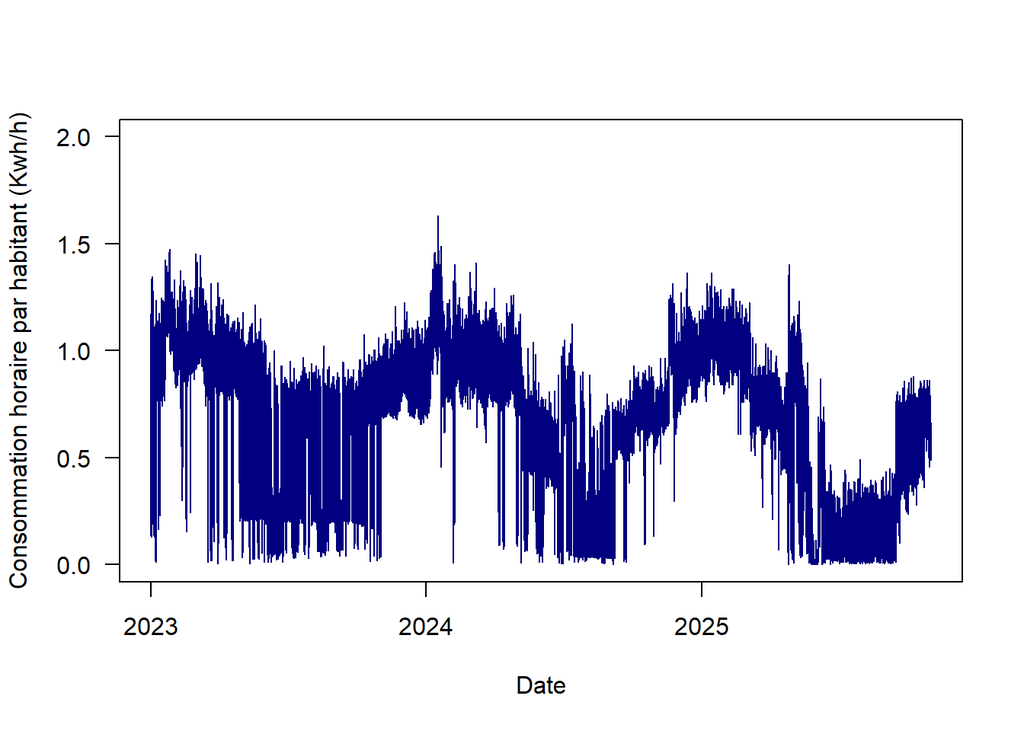

Figure 3.1: Évolution temporelle de la consommation de gaz pour le site LO

```r
plot(kWhres~DateTimeUTC, data=merged_data,
     xlab="Date", ylab="Consommation horaire par habitant (Kwh/h)",
     col="navyblue", type="l", ylim=c(0,2),las=1)
```

## 3.2 Ce que les données nous racontent

# 4 Consommation et Température : Une relation à explorer

## 4.1 Jointure et agrégation par jour

```r
daily_data <- dbGetQuery(con, "
            select
              DATE(g.DateTimeUTC) as Date,
              Month(g.DateTimeUTC) as Month,
              AVG(g.kWhres) as mean_kWh,
              AVG(s.temp) as mean_temp
            from Gas g
            left join synop s
              on g.DateTimeUTC = s.DateTimeUTC
            where g.siteName = 'LO'
            group by DATE(g.DateTimeUTC),Month(g.DateTimeUTC)
            order by DATE(g.DateTimeUTC),Month(g.DateTimeUTC)
             ")
```

```r
str(daily_data)
```

```
## 'data.frame':    1036 obs. of  4 variables:
##  $ Date     : Date, format: "2022-12-31" "2023-01-01" ...
##  $ Month    : int  12 1 1 1 1 1 1 1 1 1 ...
##  $ mean_kWh : num  0 0.711 0.924 1.009 0.872 ...
##  $ mean_temp: num  16.2 12.82 9.47 6.92 11.18 ...
```

```r
daily_data<-subset(daily_data, mean_kWh!=0)
```

## 4.2 Consommation VS Température : Le graphique revélateur

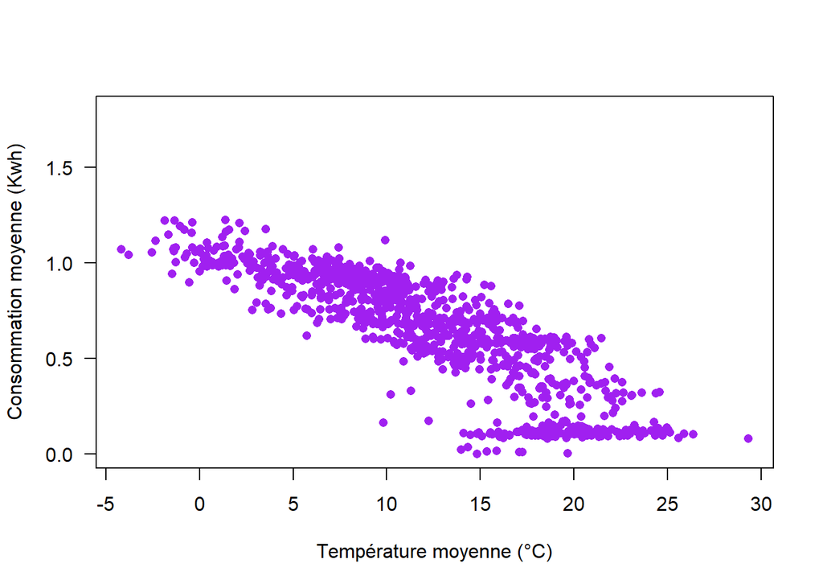

Figure 4.1: Évolution de la consommation en fonction de la température

```r
plot(mean_kWh~mean_temp, data=daily_data,pch=16,las=1,
     col="purple",ylim=c(0,1.8),xlab="Température moyenne (°C)",
     ylab="Consommation moyenne (Kwh)")
```

- Sur ce graphe, on constate que la consommation de gaz présente une relation inverse avec la température extérieure : plus la température augmente, et moins on consomme.
- À partir d’environ 15°C, la consommation devient faible, ce qui correspond à une période proche de l’été. Elle ne s’annule toutefois pas complètement, car certains usages indépendants du chauffage — comme la production d’eau chaude sanitaire ou la cuisson — continuent de générer une demande en gaz.
- À l’inverse, pour des températures comprises entre -5°C et 5°C, la consommation est nettement plus élevée, ce qui s’explique par une utilisation accrue du chauffage durant la période hivernale.

# 5 Modélisation par régression linéaire

## 5.1 Construction et définition de la variable Degré Jour (DJ)

Le DJ mesure le besoin de chauffage du site en fonction de la température intérieure de reférence de 16.5°C défini en Belgique. Au delà de 16.5°C, pas besoin de chauffage.

```r
daily_data$degre_jour<-pmax(0,16.5-daily_data$mean_temp)
```

## 5.2 Modèle de base : Consommation ~ DJ

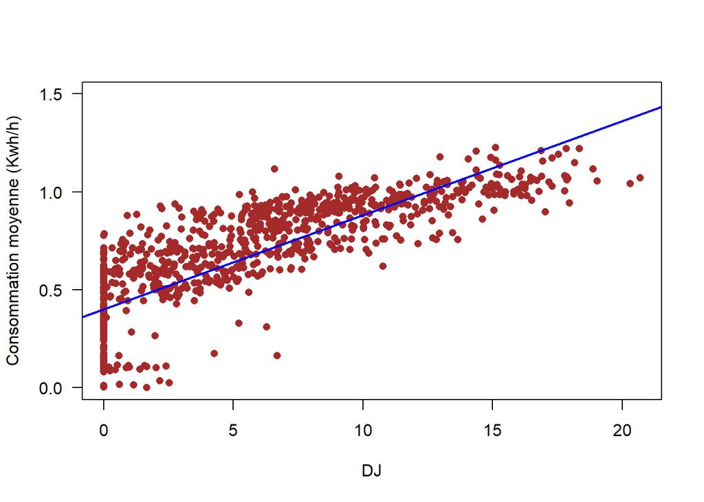

Figure 5.1: Consommation Vs Degré Jour

```r
plot(mean_kWh~degre_jour, data=daily_data,pch=16,las=1,
     ylim=c(0,1.5),
     xlab="DJ",ylab="Consommation moyenne (Kwh/h)",col="brown")
reg <- lm(mean_kWh ~ degre_jour, data = daily_data)
abline(reg, col = "blue", lwd = 2)
```

```r
summary(reg)
```

```
##
## Call:
## lm(formula = mean_kWh ~ degre_jour, data = daily_data)
##
## Residuals:
##      Min       1Q   Median       3Q      Max
## -0.55898 -0.10725  0.02301  0.13489  0.43287
##
## Coefficients:
##             Estimate Std. Error t value Pr(>|t|)
## (Intercept) 0.401416   0.007957   50.45   <2e-16 ***
## degre_jour  0.048068   0.001104   43.53   <2e-16 ***
## ---
## Signif. codes:  0 '***' 0.001 '**' 0.01 '*' 0.05 '.' 0.1 ' ' 1
##
## Residual standard error: 0.1794 on 1032 degrees of freedom
## Multiple R-squared:  0.6474, Adjusted R-squared:  0.647
## F-statistic:  1895 on 1 and 1032 DF,  p-value: < 2.2e-16
```

## 5.3 Diagnostic du modèle

### 5.3.1 Vérification des hypothèses

**Indépendance des observations**

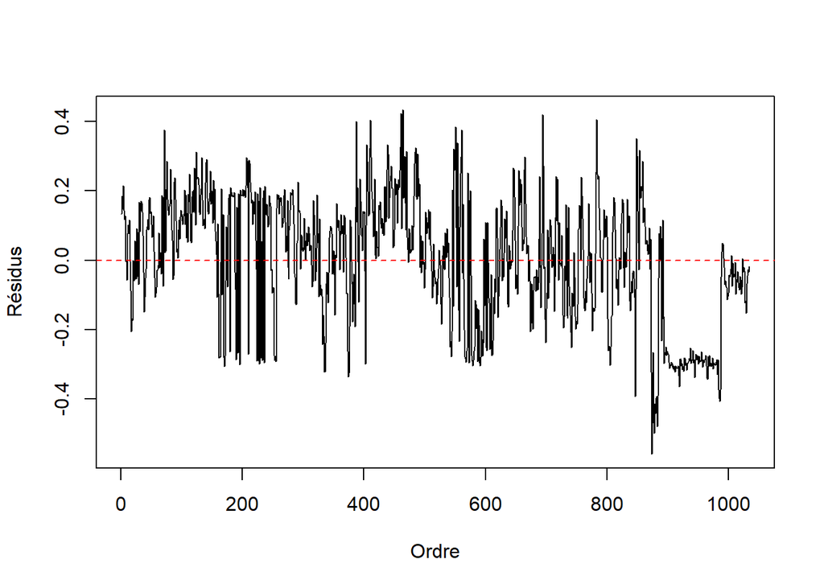

```r
plot(1:length(residuals(reg)), residuals(reg),
     type = "l", xlab = "Ordre", ylab = "Résidus")
abline(h = 0, col = "red", lty = 2)
```

**Linéarité**

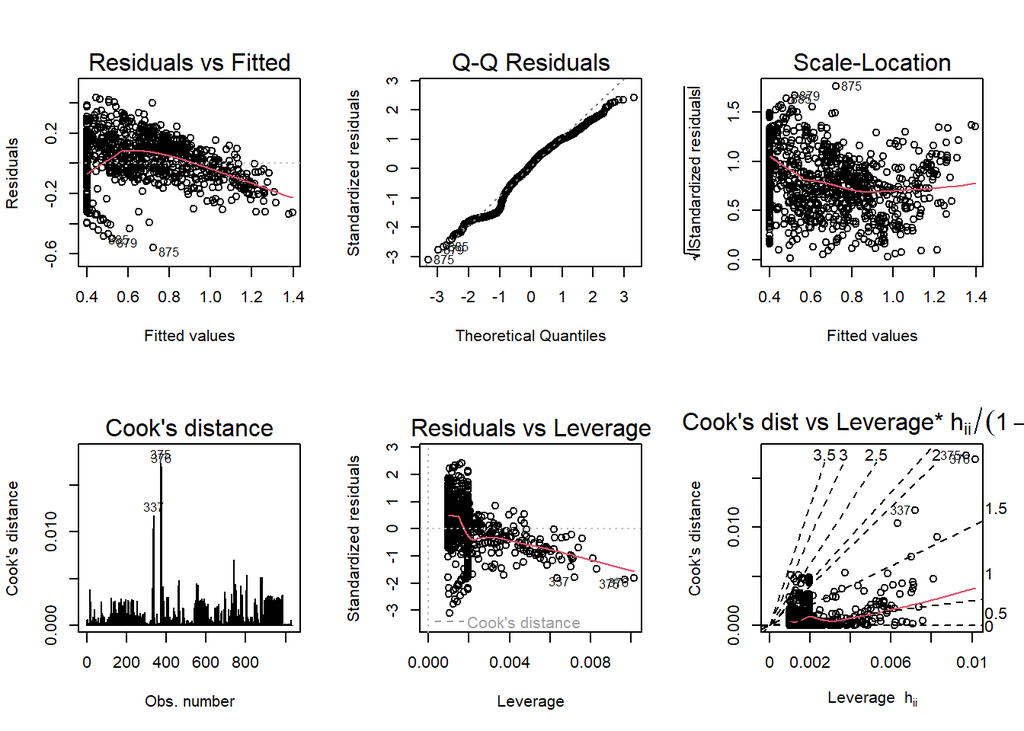

Figure 5.3: Graphe des résidus

```r
par(mfrow = c(2, 3))
plot(reg, which = 1:6)
```

```r
par(mfrow = c(1, 1))
```

Avant ajustement du modèle La tendance linéaire est clairement visible dans la figure 5.1.

**Normalité**

**Variance constante**

### 5.3.2 Interprétation des paramètres du modèle

**Test d’hypothèses** :

```
-   $H_0 : \beta_1 = 0$ (pas d'association)
-   $H_1 : \beta_1 \neq 0$ (association significative)
```

- **Résultat** : La p-valeur associée au coefficient du degré jour est < $2 \times 10^{-16}$, largement inférieure à $\alpha = 0.05$.

**Conclusion** Nous rejetons H0 : il existe une association significative entre le besoin de chauffage et la consommation de gaz. Chaque dégré supplémentaire de chauffage est associé à une augmentation moyenne de la consommation de gaz de **0.05 kwh/h**. on constate que pour une température élevée entrainant un besoin nul de chauffage, la consommation moyenne en gaz sur ce site est de 0.4 Kwh/h.

**Proportion de variabilité** Le coefficient de détermination $R^2 = 0.6474$ indique que **64.74%** de la variabilité totale de la consommation en gaz est expliquée par le dégré jour.

**Interprétation du R²** - Un $R^2$ de 0.647 est relativement élevé, suggérant que le besoin de chauffage est un bon prédicteur de la consommation en gaz. - Cependant, 35.3% de la variabilité reste inexpliquée, probablement due à d’autres facteurs (plaque à gaz, chaudière, eau chaude, etc.).

# 6 Affiner le modèle : L’effet du Mois

## 6.1 Modèle sans interaction

```r
reg_month <- lm(mean_kWh ~ degre_jour + factor(Month), data = daily_data)
```

```r
summary(reg_month)
```

```
##
## Call:
## lm(formula = mean_kWh ~ degre_jour + factor(Month), data = daily_data)
##
## Residuals:
##      Min       1Q   Median       3Q      Max
## -0.56193 -0.08592  0.00816  0.08865  0.43731
##
## Coefficients:
##                  Estimate Std. Error t value Pr(>|t|)
## (Intercept)      0.709531   0.027228  26.059  < 2e-16 ***
## degre_jour       0.023318   0.001782  13.087  < 2e-16 ***
## factor(Month)2   0.012342   0.022947   0.538   0.5908
## factor(Month)3  -0.025762   0.023386  -1.102   0.2709
## factor(Month)4  -0.056297   0.025244  -2.230   0.0260 *
## factor(Month)5  -0.181934   0.028601  -6.361 3.02e-10 ***
## factor(Month)6  -0.391913   0.030645 -12.789  < 2e-16 ***
## factor(Month)7  -0.360848   0.031223 -11.557  < 2e-16 ***
## factor(Month)8  -0.437628   0.031089 -14.076  < 2e-16 ***
## factor(Month)9  -0.321114   0.029816 -10.770  < 2e-16 ***
## factor(Month)10 -0.174819   0.026889  -6.501 1.24e-10 ***
## factor(Month)11 -0.104644   0.025744  -4.065 5.17e-05 ***
## factor(Month)12 -0.048338   0.025000  -1.934   0.0535 .
## ---
## Signif. codes:  0 '***' 0.001 '**' 0.01 '*' 0.05 '.' 0.1 ' ' 1
##
## Residual standard error: 0.1506 on 1021 degrees of freedom
## Multiple R-squared:  0.754,  Adjusted R-squared:  0.7511
## F-statistic: 260.8 on 12 and 1021 DF,  p-value: < 2.2e-16
```

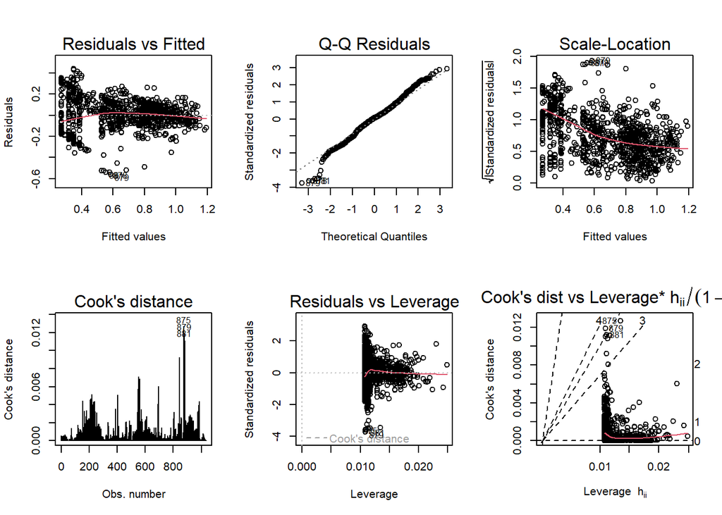

```r
par(mfrow = c(2, 3))
plot(reg_month, which = 1:6)
```

```r
reg_month_interaction <- lm(mean_kWh ~ degre_jour * factor(Month), data = daily_data)
```

```r
summary(reg_month_interaction)
```

```
##
## Call:
## lm(formula = mean_kWh ~ degre_jour * factor(Month), data = daily_data)
##
## Residuals:
##      Min       1Q   Median       3Q      Max
## -0.62662 -0.08435  0.00580  0.07540  0.45963
##
## Coefficients:
##                             Estimate Std. Error t value Pr(>|t|)
## (Intercept)                 0.748453   0.046272  16.175  < 2e-16 ***
## degre_jour                  0.020208   0.003500   5.774 1.03e-08 ***
## factor(Month)2              0.098839   0.067414   1.466 0.142921
## factor(Month)3             -0.003671   0.061437  -0.060 0.952369
## factor(Month)4             -0.135531   0.056246  -2.410 0.016148 *
## factor(Month)5             -0.279288   0.052095  -5.361 1.02e-07 ***
## factor(Month)6             -0.461894   0.049399  -9.350  < 2e-16 ***
## factor(Month)7             -0.424418   0.048835  -8.691  < 2e-16 ***
## factor(Month)8             -0.513181   0.049006 -10.472  < 2e-16 ***
## factor(Month)9             -0.387308   0.049775  -7.781 1.77e-14 ***
## factor(Month)10            -0.195061   0.054003  -3.612 0.000319 ***
## factor(Month)11            -0.079582   0.076491  -1.040 0.298399
## factor(Month)12            -0.002345   0.078552  -0.030 0.976190
## degre_jour:factor(Month)2  -0.009066   0.005711  -1.588 0.112676
## degre_jour:factor(Month)3  -0.004322   0.005760  -0.750 0.453294
## degre_jour:factor(Month)4   0.010001   0.005951   1.680 0.093177 .
## degre_jour:factor(Month)5   0.027844   0.008638   3.224 0.001307 **
## degre_jour:factor(Month)6   0.047205   0.012336   3.827 0.000138 ***
## degre_jour:factor(Month)7   0.188655   0.035016   5.388 8.88e-08 ***
## degre_jour:factor(Month)8   0.156446   0.026102   5.994 2.85e-09 ***
## degre_jour:factor(Month)9   0.022695   0.008205   2.766 0.005776 **
## degre_jour:factor(Month)10 -0.001665   0.006955  -0.239 0.810845
## degre_jour:factor(Month)11 -0.004043   0.007369  -0.549 0.583342
## degre_jour:factor(Month)12 -0.005099   0.006840  -0.745 0.456185
## ---
## Signif. codes:  0 '***' 0.001 '**' 0.01 '*' 0.05 '.' 0.1 ' ' 1
##
## Residual standard error: 0.1438 on 1010 degrees of freedom
## Multiple R-squared:  0.7783, Adjusted R-squared:  0.7733
## F-statistic: 154.2 on 23 and 1010 DF,  p-value: < 2.2e-16
```

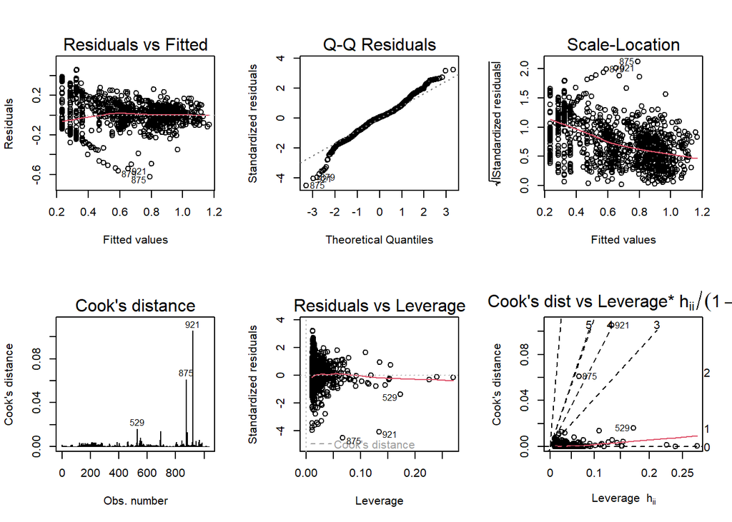

```r
par(mfrow = c(2, 3))
plot(reg_month_interaction, which = 1:6)
```

Ce modèle indique que l’effet de la température change selon le mois, ce qui semble plus réaliste. La pente dépend du mois. Le coefficient de détermination $R^2 = 0.7783$ est plus élevé que les deux modèles précédents.

## 6.2 Comparaison des trois modèles

```r
# --- Calcul des métriques R² pour chaque modèle ---
tableau_r2 <- data.frame(
  Modèle = c(
    "Modèle 1 — Base (DJ)",
    "Modèle 2 — Sans interaction (DJ + Mois)",
    "Modèle 3 — Interactif (DJ × Mois)"
  ),
  R2_brut = c(
    round(summary(reg)$r.squared, 4),
    round(summary(reg_month)$r.squared, 4),
    round(summary(reg_month_interaction)$r.squared, 4)
  ),
  R2_ajuste = c(
    round(summary(reg)$adj.r.squared, 4),
    round(summary(reg_month)$adj.r.squared, 4),
    round(summary(reg_month_interaction)$adj.r.squared, 4)
  ),
  R2_pct = c(
    paste0(round(summary(reg)$r.squared * 100, 1), " %"),
    paste0(round(summary(reg_month)$r.squared * 100, 1), " %"),
    paste0(round(summary(reg_month_interaction)$r.squared * 100, 1), " %")
  ),
  R2_adj_pct = c(
    paste0(round(summary(reg)$adj.r.squared * 100, 1), " %"),
    paste0(round(summary(reg_month)$adj.r.squared * 100, 1), " %"),
    paste0(round(summary(reg_month_interaction)$adj.r.squared * 100, 1), " %")
  ),
  Gain_R2 = c(
    "—",
    paste0("+ ", round((summary(reg_month)$r.squared - summary(reg)$r.squared) * 100, 1), " %"),
    paste0("+ ", round((summary(reg_month_interaction)$r.squared - summary(reg_month)$r.squared) * 100, 1), " %")
  )
)

# --- Affichage du tableau ---
kable(tableau_r2,
      caption = "Comparaison de la proportion de variabilité expliquée par les modèles",
      col.names = c("Modèle", "R²", "R² Ajusté",
                    "R² (%)", "R² Ajusté (%)", "Gain R² vs modèle précédent"),
      align = c("l", "c", "c", "c", "c", "c")) |>
  kable_styling(
    bootstrap_options = c("striped", "hover", "bordered"),
    full_width = TRUE,
    font_size = 13
  ) |>
  # En-tête
  row_spec(0, bold = TRUE, background = "#2C3E50", color = "white") |>
  # Mise en évidence du meilleur modèle
  row_spec(which.max(tableau_r2$R2_ajuste),
           bold = TRUE,
           background = "#D5F5E3",
           color = "#1E8449") |>
  # Groupement
  pack_rows("Sans effet mensuel", 1, 1) |>
  pack_rows("Avec effet mensuel", 2, 3) |>
  # Double en-tête
  add_header_above(c(" " = 1,
                     "Valeurs brutes" = 2,
                     "En pourcentage" = 2,
                     " " = 1)) |>
  footnote(
    general = "R² : proportion de la variabilité totale de la consommation expliquée par le modèle.
               R² Ajusté : R² corrigé du nombre de paramètres — critère de comparaison recommandé.
               La ligne en vert correspond au modèle retenu.",
    general_title = "Note : ",
    footnote_as_chunk = TRUE
  )
```

Table 6.1: Table 6.2: Comparaison de la proportion de variabilité expliquée par les modèles

Valeurs brutes

En pourcentage

Modèle

R²

R² Ajusté

R² (%)

R² Ajusté (%)

Gain R² vs modèle précédent

**Sans effet mensuel**

Modèle 1 — Base (DJ)

0.6474

0.6470

64.7 %

64.7 %

—

**Avec effet mensuel**

Modèle 2 — Sans interaction (DJ + Mois)

0.7540

0.7511

75.4 %

75.1 %

Modèle 3 — Interactif (DJ × Mois)

0.7783

0.7733

77.8 %

77.3 %

Note : R² : proportion de la variabilité totale de la consommation expliquée par le modèle.  
R² Ajusté : R² corrigé du nombre de paramètres — critère de comparaison recommandé.  
La ligne en vert correspond au modèle retenu.

# 7 Portrait énergétique des 17 sites

## 7.1 Extraction des consommations moyennes mensuelles par site

```r
Monthly_data <- dbGetQuery(con, "
            Select
              siteName,
              Month(DateTimeUTC) as Month,
              AVG(kWhres) AS Mean_kWh
            from Gas
            group by
              siteName,
              Month(DateTimeUTC)")
```

**Fermeture de connexion**

```r
dbDisconnect(con)
dbUnloadDriver(mgr)
```

```
## [1] TRUE
```

## 7.2 Visualisation de la matrice

```r
Matrice <- tapply(Monthly_data$Mean_kWh,
                  list(Monthly_data$siteName, Monthly_data$Month),
                  FUN = mean)
dim(Matrice)
```

```
## [1] 17 12
```

# 8 Analyse en composantes principales : ACP

## 8.1 Réalisation de l’ACP

```r
res.PCA <- PCA(Matrice, scale.unit = TRUE, ncp = 10, graph = FALSE)
```

```r
res.PCA$eig
```

```
##           eigenvalue percentage of variance cumulative percentage of variance
## comp 1  1.059477e+01           88.289714903                          88.28971
## comp 2  1.096440e+00            9.137002365                          97.42672
## comp 3  1.420705e-01            1.183920981                          98.61064
## comp 4  6.277196e-02            0.523099650                          99.13374
## comp 5  4.324689e-02            0.360390791                          99.49413
## comp 6  2.878900e-02            0.239908300                          99.73404
## comp 7  1.609601e-02            0.134133377                          99.86817
## comp 8  7.623293e-03            0.063527438                          99.93170
## comp 9  4.615381e-03            0.038461509                          99.97016
## comp 10 1.869407e-03            0.015578388                          99.98574
## comp 11 1.348633e-03            0.011238610                          99.99698
## comp 12 3.628425e-04            0.003023688                         100.00000
```

## 8.2 Interprétation des axes factoriels

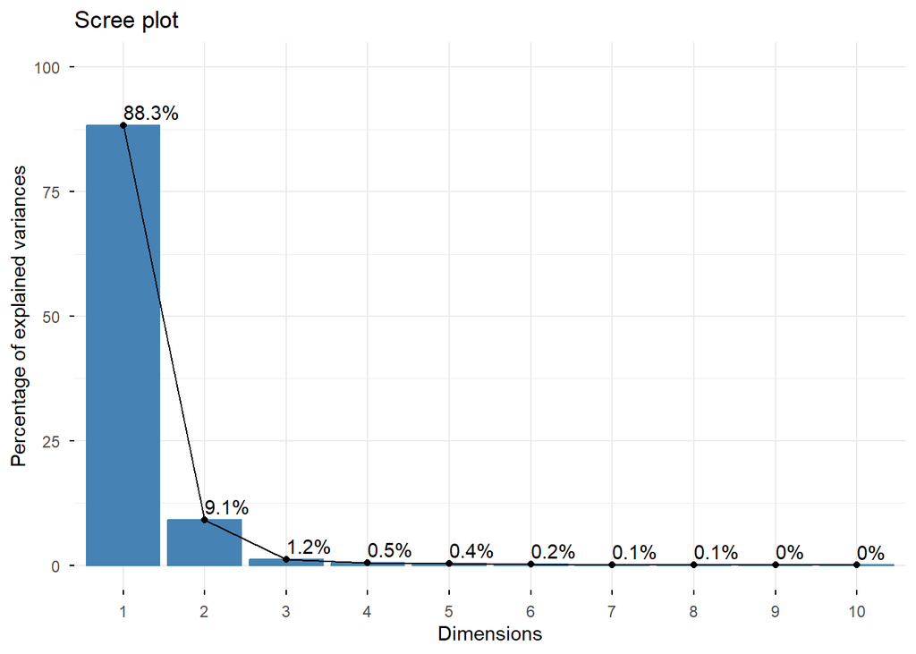

```r
fviz_eig(res.PCA, addlabels = TRUE, ylim = c(0, 100))
```

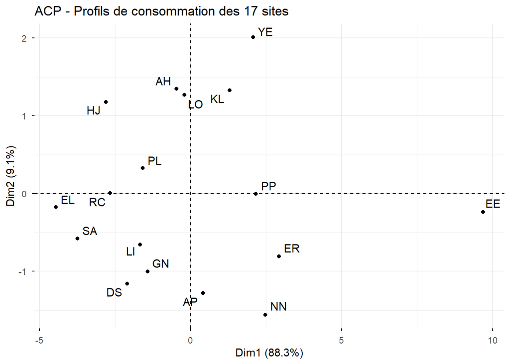

```r
fviz_pca_ind(res.PCA, repel = TRUE,
             title = "ACP - Profils de consommation des 17 sites")
```

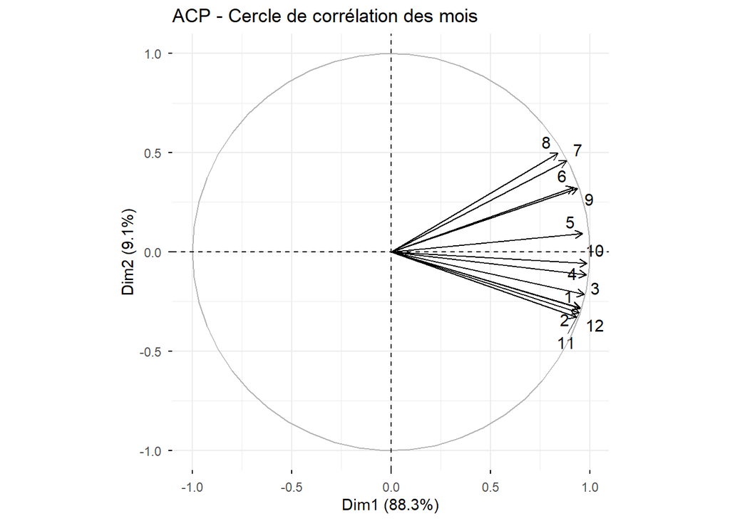

```r
fviz_pca_var(res.PCA, repel = TRUE,
             title = "ACP - Cercle de corrélation des mois")
```

## 8.3 Ce que l’ACP révèle sur les profils de consommation

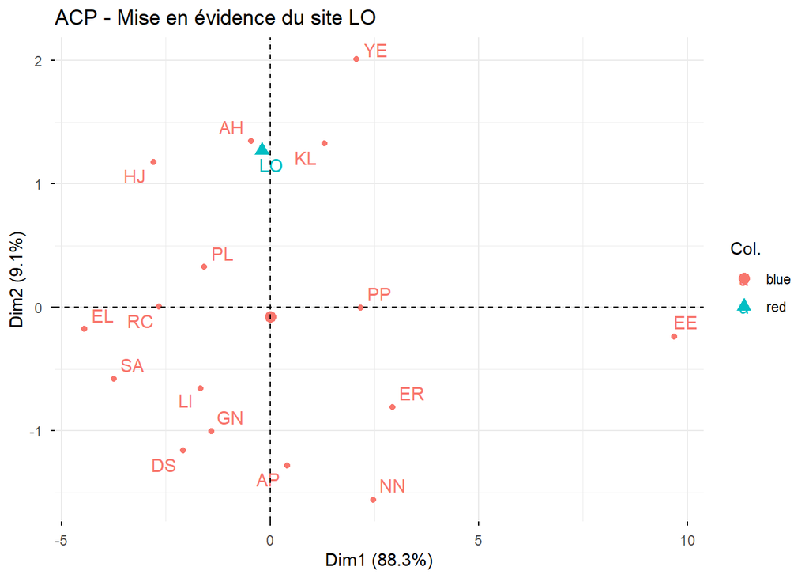

```r
couleurs_sites <- ifelse(rownames(Matrice) == "LO", "red", "blue")

fviz_pca_ind(res.PCA,
             col.ind = couleurs_sites,
             repel   = TRUE,
             title   = "ACP - Mise en évidence du site LO")
```

Le graphe de corrélation des mois ne nous indique pas vraiment quel est le mois qui se distingue. Par contre sur le profil de consommation des 17 sites, on voit clairement que le site **EE** se démarque fortement des autres sites.

# 9 Clasification des sites : Qui consomme comme qui ?

## 9.1 Analyse en clusters

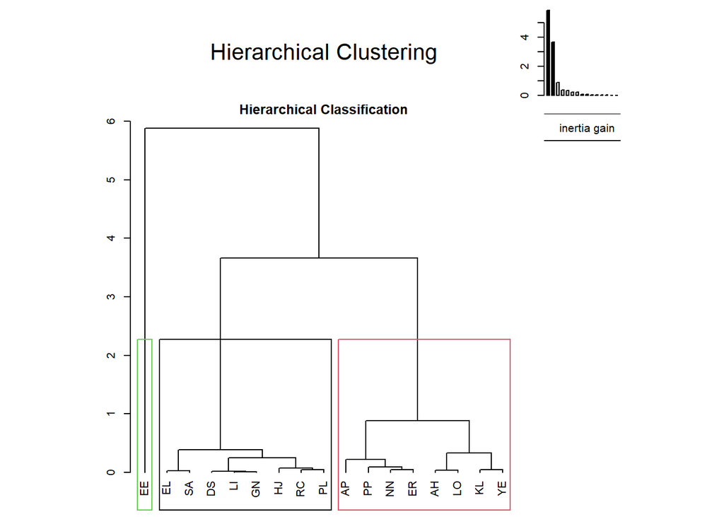

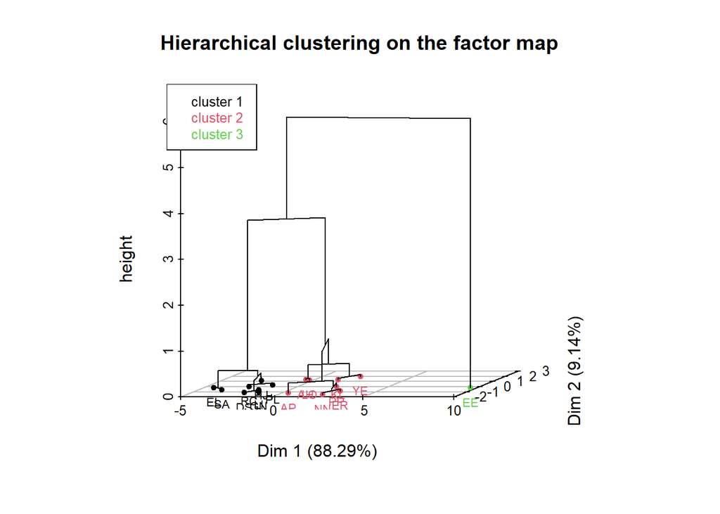

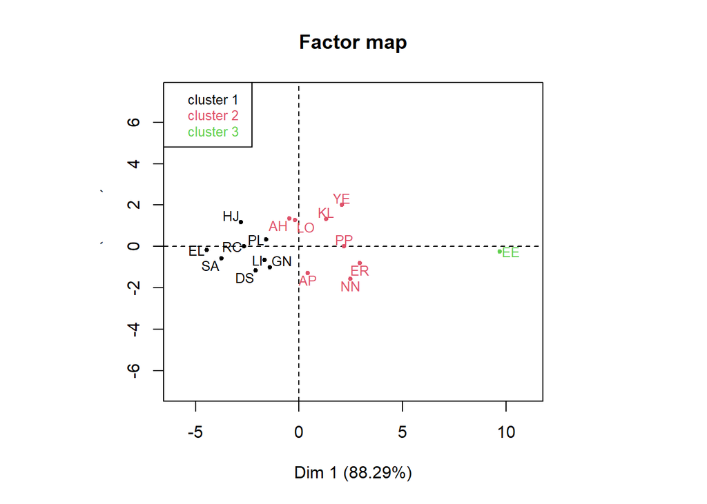

```r
res.hcpc <- HCPC(res  = res.PCA,
                 nb.clust = -1,
                 consol   = TRUE,
                 min      = 3,
                 max      = 10,
                 graph    = TRUE,
                 metric   = "euclidean",
                 method   = "ward")
```

**Dendogramme**

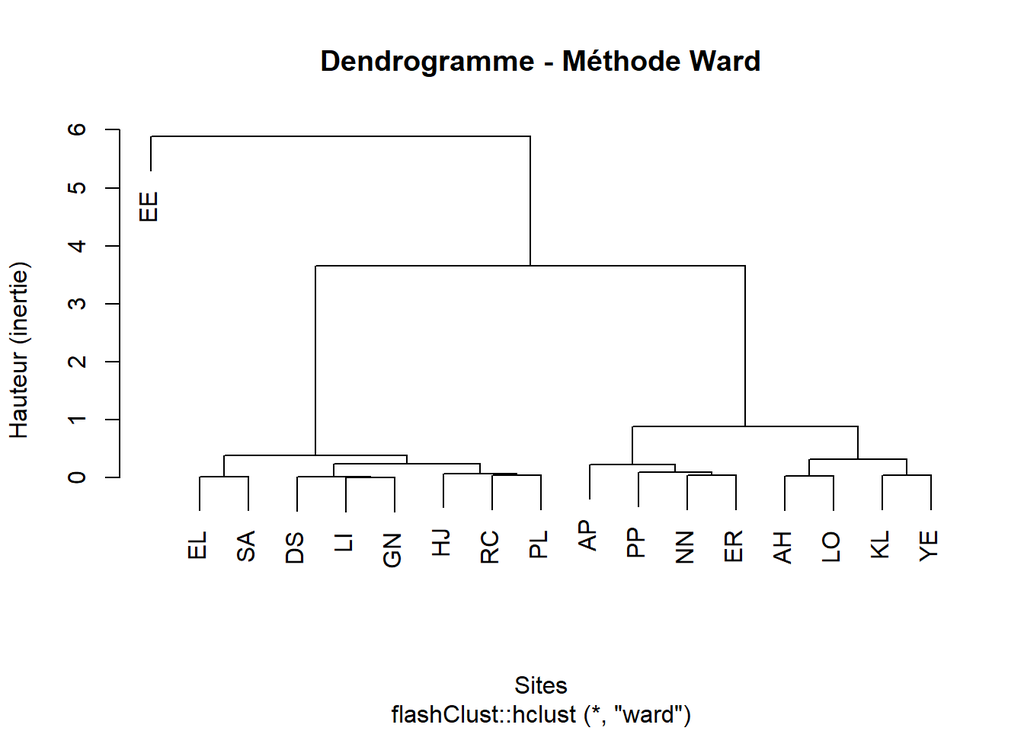

```r
plot(res.hcpc$call$t$tree,
     main  = "Dendrogramme - Méthode Ward",
     xlab  = "Sites",
     ylab  = "Hauteur (inertie)")
```

## 9.2 Profil de chaque groupe

```r
res.hcpc$data.clust
```

```
##            1         2         3         4         5         6         7
## AH 1.0216372 0.6975948 0.8919832 0.7352097 0.5628956 0.3739899 0.3151483
## AP 1.3795470 1.2937738 1.0292578 0.7839045 0.5178192 0.3000782 0.2209684
## DS 1.1912502 1.0476321 0.8748762 0.6247587 0.3154499 0.1968654 0.1675396
## EE 2.4595777 2.1944501 1.8800856 1.5105328 0.9287526 0.6906354 0.5307946
## EL 0.7428239 0.6521179 0.5528858 0.4389687 0.2956460 0.1891215 0.1358994
## ER 1.7200172 1.5103586 1.2803935 1.0167504 0.6488920 0.3173330 0.3447588
## GN 1.2966792 1.1008168 0.8830095 0.6621666 0.3680580 0.2393745 0.1984078
## HJ 0.8392977 0.7112374 0.6011759 0.4866580 0.3346614 0.2600388 0.2421156
## KL 1.2831523 1.1080157 0.9406592 0.7695973 0.5470100 0.3998519 0.3753780
## LI 1.1954437 1.0211542 0.8470688 0.6252998 0.3567677 0.2449169 0.2044371
## LO 1.0013787 0.9620516 0.8752164 0.7896293 0.5764156 0.3340415 0.3517810
## NN 1.6663538 1.5106774 1.2473143 0.9930180 0.6584063 0.3373787 0.2799217
## PL 1.0494254 0.9093430 0.7857724 0.6284287 0.4099499 0.2985294 0.2639757
## PP 1.5075086 1.3387930 1.1363030 0.9551408 0.5961656 0.4344088 0.3566601
## RC 0.9006208 0.7999204 0.7170401 0.5752108 0.3768414 0.2445573 0.1894955
## SA 0.8977409 0.7776208 0.6353653 0.4894309 0.2722717 0.1862148 0.1456594
## YE 1.3695255 1.1676674 0.9832429 0.7878084 0.5700896 0.4718793 0.4398537
##            8         9        10        11        12 clust
## AH 0.3107281 0.3657566 0.5830680 0.8694842 0.9737393     2
## AP 0.1974694 0.3405620 0.7223481 1.2259290 1.2747282     2
## DS 0.1814067 0.2431572 0.4929413 0.8994360 1.0662443     1
## EE 0.5078640 0.6927600 1.2227990 1.9200239 2.0416285     3
## EL 0.1276722 0.1819294 0.3771885 0.5968182 0.6800490     1
## ER 0.3411649 0.4244577 0.7908727 1.3557228 1.5260225     2
## GN 0.1877907 0.2817094 0.5154278 0.9671974 1.1068490     1
## HJ 0.2740383 0.3080397 0.5088873 0.6272687 0.7233617     1
## KL 0.3802375 0.4766983 0.7223687 1.0500765 1.1686547     2
## LI 0.2074311 0.2741698 0.5107018 0.9273283 1.0673563     1
## LO 0.2774729 0.4208860 0.6259367 0.8134629 0.9018064     2
## NN 0.2325725 0.3964122 0.8222500 1.4234496 1.4921478     2
## PL 0.2094167 0.3237012 0.5564640 0.7772827 0.9541123     1
## PP 0.3105140 0.4024073 0.7425387 1.2131465 1.3615079     2
## RC 0.1751551 0.2860229 0.5034874 0.7635968 0.8242826     1
## SA 0.1345750 0.2060410 0.4351734 0.7328890 0.7916426     1
## YE 0.4511315 0.5082800 0.6773232 1.0620747 1.2151050     2
```

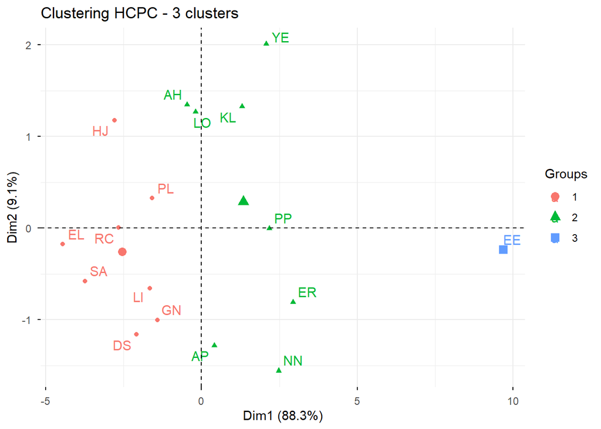

```r
fviz_pca_ind(res.PCA,
             habillage = res.hcpc$data.clust$clust,
             repel     = TRUE,
             title     = "Clustering HCPC - 3 clusters")
```

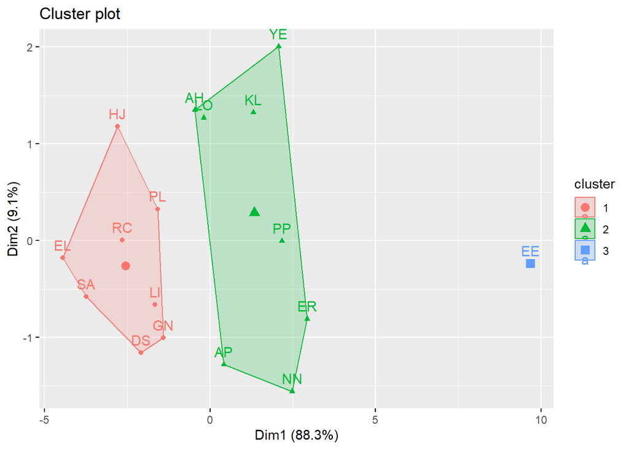

```r
fviz_cluster(res.hcpc)
```

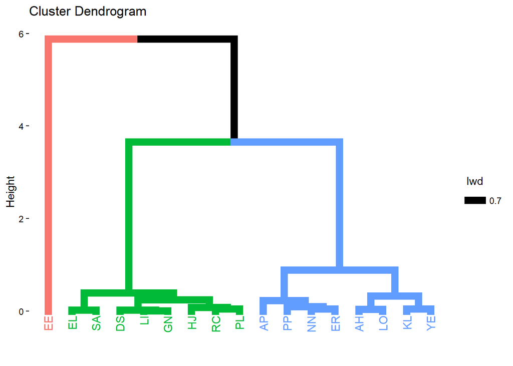

```r
fviz_dend(res.hcpc)
```

## 9.3 Recommandations ciblées par groupe

On constate que le site EE a une consommation anormalement élevée et on peut se demander si ce n’est pas du à une panne ou un dérèglement, Donc c’est un site à suivre de près.

# Conclusion générale

Pour ce projet, nous pouvons déduire que la température extérieure est le principal moteur de la consommation de gaz résidentielle. Chaque degré de moins en Hiver se traduit par une hausse de la demande énergétique. On constate également que le site **EE** mérite une investigation approfondie. Le site **LO** qui a porté mon attention pour ce projet présente une consommation modérée et un profil plus ou moins stable.